# Modelo de Riesgo financiero con GARCH

En este proyecto, construiremos un modelo para estudiar la naturaleza de la volatilidad en el caso de los rentabilidades de bonos del gobierno de los Estados Unidos. El riesgo financiero tiene muchas caras y se mide de diversas formas, pero por ahora, acordemos que es una medida de la posible pérdida en una inversión. En los mercados financieros, donde medimos los precios con frecuencia, la volatilidad (que es análoga a la desviación estándar) es una elección obvia para medir el riesgo.

Estos datos incluyen toda la curva de rentabilidades. El rendimiento de un bono es el precio del dinero prestado. Cuanto mayor sea el rendimiento, más dinero se recibe en la inversión. La curva de rendimiento tiene muchas implicancias; en este caso, abarca desde 1 año hasta 30 años. Diferentes vencimientos tienen diferentes rentabilidades, pero los rentabilidades de vencimientos cercanas son relativamente cercanos entre sí y también se mueven juntos.

```r
# Cargar los páquetes
library(xts)
library(readr)

# Load the data
choose.files()
```

```
character(0)
```

```r
yc_raw <- read_csv("C:\\Users\\User\\Desktop\\datasets\\proy 2\\FED-SVENY.csv")
# Convert the data into xts format

yc_all <- as.xts(x = yc_raw[, -1], order.by = yc_raw$Date)

# Show only the tail of the 1st, 5th, 10th, 20th and 30th columns
yc_all_tail <- tail(yc_all[,c(1,5,10,20,30)])
yc_all_tail
```

```
           SVENY01 SVENY05 SVENY10 SVENY20 SVENY30
2019-03-22  2.4222  2.2613  2.4553  2.7661  3.0178
2019-03-25  2.3901  2.2281  2.4449  2.7610  3.0216
2019-03-26  2.3811  2.2016  2.4249  2.7508  3.0138
2019-03-27  2.3560  2.1931  2.4020  2.7092  2.9785
2019-03-28  2.3601  2.2137  2.4058  2.6907  2.9605
2019-03-29  2.3719  2.2398  2.4143  2.6939  2.9538
```

Visualicemos los rentabilidades a lo largo del tiempo. Veremos que los rentabilidades a largo plazo (por ejemplo, SVENY30) tienden a ser más estables a largo plazo, mientras que los rentabilidades a corto plazo (por ejemplo, SVENY01) varían mucho. Estos movimientos están relacionados con la política monetaria de la Reserva Federal (FED) y la economía.

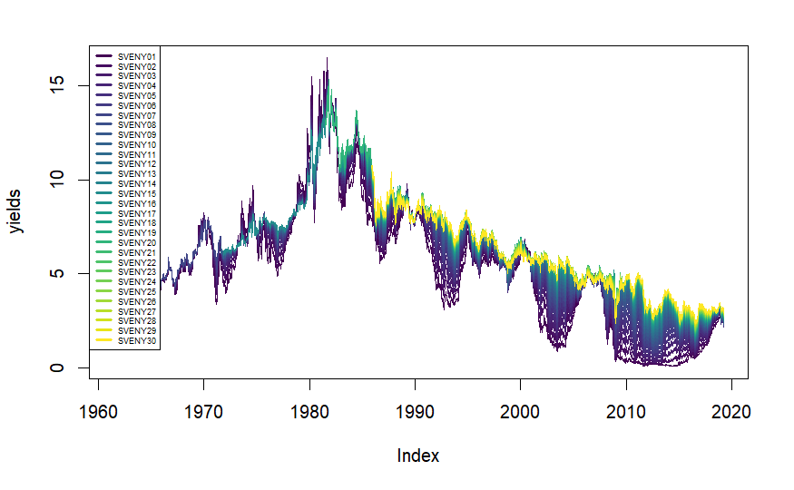

```r
library(viridis)
# Define plot arguments
yields  <- yc_all
plot.type  <- 'single'
plot.palette <- viridis(n=30)
asset.names  <- colnames(yc_all)

# Plot the time series
plot.zoo(x = yields, plot.type = 'single', col = plot.palette)

# Add the legend
legend(x = "topleft", legend = asset.names,
       col = plot.palette, cex = 0.45, lwd = 3)
```

vemos el nivel de las rentabilidades de los bonos para diferentes vencimientos a lo largo del tiempo. Sin embargo, para comprender cómo evoluciona la volatilidad, debemos examinar los cambios en la serie temporal. Actualmente, tenemos los niveles de rendimiento; necesitamos calcular los cambios en los niveles de rendimiento. Esto se conoce como “diferenciación” en el análisis de series temporales. La diferenciación tiene la ventaja adicional de hacer que una serie temporal sea independiente del tiempo.

```r
ycc_all_tail
```

```
           SVENY01 SVENY05 SVENY10 SVENY20 SVENY30
2019-03-22 -0.0412 -0.1039 -0.0878 -0.0924 -0.0864
2019-03-25 -0.0321 -0.0332 -0.0104 -0.0051  0.0038
2019-03-26 -0.0090 -0.0265 -0.0200 -0.0102 -0.0078
2019-03-27 -0.0251 -0.0085 -0.0229 -0.0416 -0.0353
2019-03-28  0.0041  0.0206  0.0038 -0.0185 -0.0180
2019-03-29  0.0118  0.0261  0.0085  0.0032 -0.0067
```

Ahora que tenemos una serie temporal de los cambios en las rentabilidades de los bonos del gobierno de los Estados Unidos, examinemosla visualmente.

Al observar la serie temporal de los cambios de rendimiento en los gráficos anteriores, podemos ver indicios de que los rentabilidades que se suceden tienen algunas propiedades únicas:

La dirección (positiva o negativa) de un cambio de rendimiento es principalmente independiente del cambio de rendimiento del día anterior. En otras palabras, no se puede predecir si el cambio de rendimiento del próximo día será positivo o negativo solo mirando la serie temporal.

La magnitud del cambio de rendimiento es similar al cambio de rendimiento del día anterior. Esto significa que si los mercados están tranquilos hoy, esperamos que sean igualmente tranquilos mañana. Sin embargo, en un mercado volátil (durante una crisis), debemos esperar un día igualmente turbulento.

En resumen, estos patrones sugieren que el comportamiento de los cambios de rendimiento no está fuertemente correlacionado de un día a otro en términos de dirección (positiva o negativa), pero la magnitud de los cambios tiende a mantenerse similar al día anterior. Esto tiene implicaciones importantes para el análisis de la volatilidad y el riesgo en los mercados financieros.

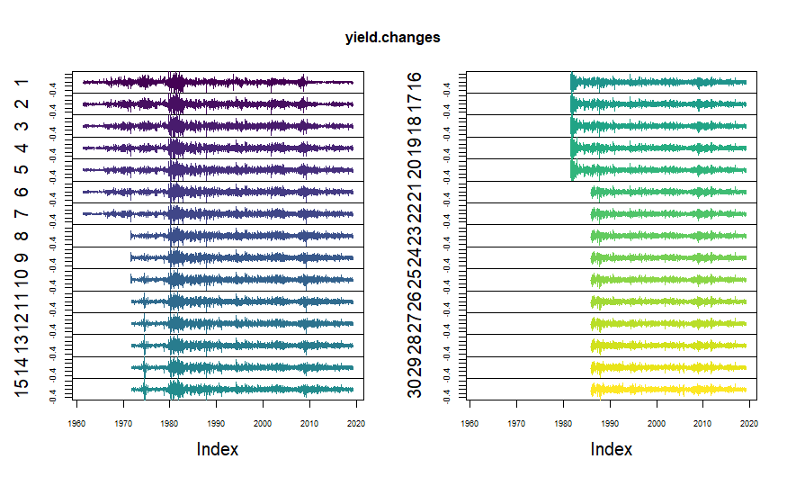

Las propiedades estadísticas que visualizamos anteriormente pueden medirse mediante herramientas analíticas. El método más sencillo es probar la autocorrelación. La autocorrelación mide cómo el pasado de un punto de datos determina el futuro de una serie temporal.

Si la autocorrelación está cerca de 1, el valor del día siguiente será muy cercano al valor de hoy. Si la autocorrelación está cerca de 0, el valor del día siguiente no se verá afectado por el valor de hoy.

Dado que estamos interesados en la evolución reciente de los rentabilidades de los bonos, filtraremos la serie temporal para obtener datos desde el año 2000 en adelante. Esto nos permitirá analizar cómo el pasado influye en los rentabilidades actuales en el período más relevante para nuestra investigación.

```r
# Filter for changes in and after 2000
ycc <- ycc_all['2000/']

# Save the 1-year and 20-year maturity yield changes into separate variables
x_1 <- ycc[,'SVENY01']
x_20 <- ycc[,'SVENY20']

# Plot the autocorrelations of the yield changes
par(mfrow=c(2,2))
acf_1 <- acf(x_1)
acf_20 <- acf(x_20)
```

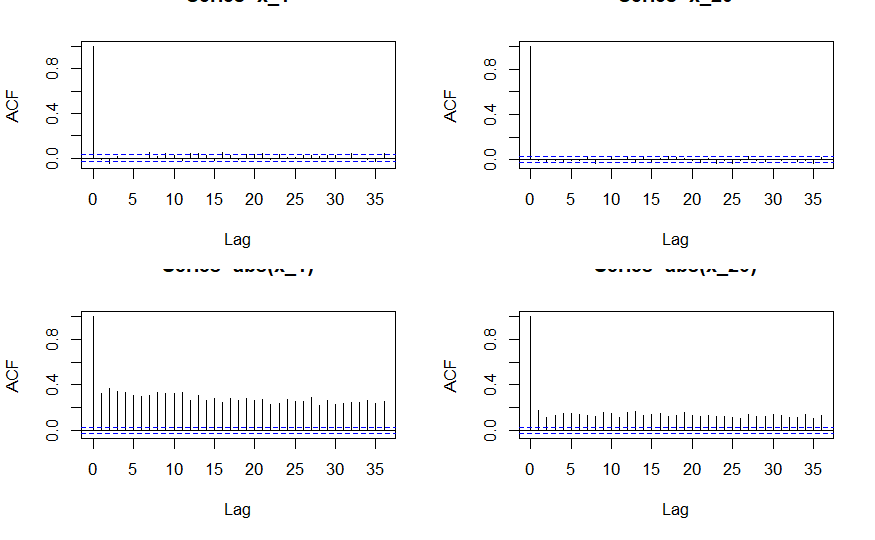

```r
# Plot the autocorrelations of the absolute changes of yields
acf_abs_1 <- acf(abs(x_1))
acf_abs_20 <- acf(abs(x_20))
```

Un modelo de AutoRegressive Conditional Heteroskedasticity Generalizado (GARCH) es la herramienta econométrica más conocida para manejar la volatilidad cambiante en datos de series temporales financieras. Este modelo asume la existencia de una variable de volatilidad oculta que tiene un promedio a largo plazo al cual tiende a regresar, mientras que su comportamiento a corto plazo es afectado por los rentabilidades pasados.

La forma más popular del modelo GARCH asume que la volatilidad sigue este proceso:

σ2t = ω + α ⋅ ε2t-1 + β ⋅ σ2t-1

Donde σ2t representa la volatilidad en el tiempo t, εt-1 es el rendimiento del día anterior, y α, β y ω son parámetros estimados.

Para modelar GARCH, utilizaremos el paquete “rugarch” desarrollado por Alexios Ghalanos. Este paquete es ampliamente utilizado en análisis financiero y econometría para modelar la volatilidad y el riesgo en datos de series temporales.

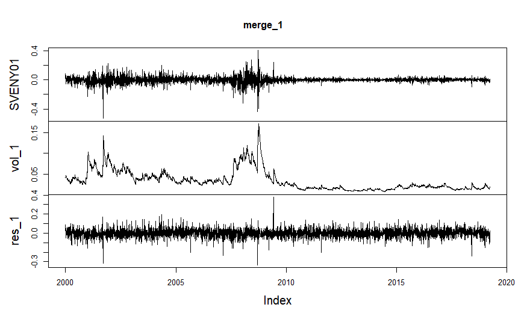

```r
library(rugarch)

# Specify the GARCH model with the skewed t-distribution
spec <- ugarchspec(distribution.model = 'sstd')

# Fit the model
fit_1 <- ugarchfit(x_1, spec = spec)

# Save the volatilities and the rescaled residuals
vol_1 <- sigma(fit_1)
res_1 <- scale(residuals(fit_1, standardize = TRUE)) * sd(x_1) + mean(x_1)

# Plot the yield changes with the estimated volatilities and residuals
merge_1 <- merge.xts(x_1, vol_1, res_1)
plot.zoo(merge_1)
```

Realicemos lo mismo para la madurez de 20 años. Como podemos ver en el gráfico de la Tarea 6, los rentabilidades de los bonos con diversas madureces muestran características similares pero ligeramente diferentes. Estas diferencias pueden ser el resultado de múltiples factores, como la política monetaria de la Reserva Federal (FED) o el hecho de que los inversores podrían ser distintos.

¿Existen diferencias entre los gráficos de la madurez de 1 año y la madurez de 20 años?